# UTS Regression Models

Dila Ananda Oktafiani-Rekayasa Perangkat Lunak

2025-05-05

# Soal 1

## Membuat Correlation Matrix

```r
library(corrplot)
# Membaca data
HeatingOil <- read.csv("HeatingOil.csv")

# Menampilkan 6 baris pertama
head(HeatingOil)
```

|  | Insulation | Temperature | Heating_Oil | Num_Occupants | Avg_Age | Home_Size |
| --- | --- | --- | --- | --- | --- | --- |
| 1 | 6 | 74 | 132 | 4 | 23.8 | 4 |
| 2 | 10 | 43 | 263 | 4 | 56.7 | 4 |
| 3 | 3 | 81 | 145 | 2 | 28.0 | 6 |
| 4 | 9 | 50 | 196 | 4 | 45.1 | 3 |
| 5 | 2 | 80 | 131 | 5 | 20.8 | 2 |
| 6 | 5 | 76 | 129 | 3 | 21.5 | 3 |

```r
# Menampilkan Korelasi
cor_matrix <- round(cor(HeatingOil, use = "complete.obs"), 2)
cor_matrix
```

```
##               Insulation Temperature Heating_Oil Num_Occupants Avg_Age
## Insulation          1.00       -0.79        0.74         -0.01    0.64
## Temperature        -0.79        1.00       -0.77          0.01   -0.67
## Heating_Oil         0.74       -0.77        1.00         -0.04    0.85
## Num_Occupants      -0.01        0.01       -0.04          1.00   -0.05
## Avg_Age             0.64       -0.67        0.85         -0.05    1.00
## Home_Size           0.20       -0.21        0.38         -0.02    0.31
##               Home_Size
## Insulation         0.20
## Temperature       -0.21
## Heating_Oil        0.38
## Num_Occupants     -0.02
## Avg_Age            0.31
## Home_Size          1.00
```

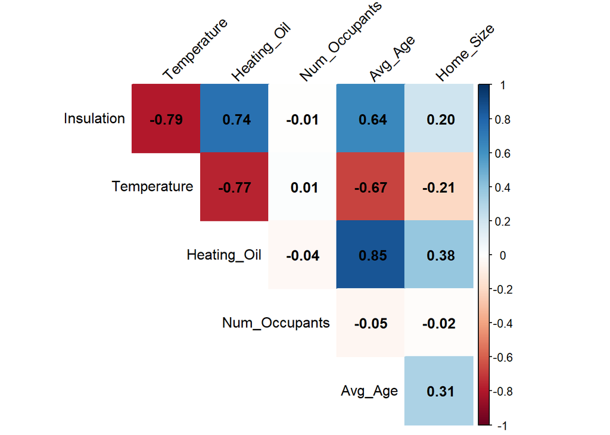

```r
# Visualisasi Heatmap Korelasi
corrplot(cor_matrix, method = "color", type = "upper",
         addCoef.col = "black", tl.col = "black",
         tl.srt = 45, diag = FALSE)
```

## Interpretasi Correlation Matrix

Penjelasan:

**1. Avg_Age (+0.85) – Korelasi Kuat dan Positif** semakin tinggi rata-rata usia penghuni rumah, semakin banyak penggunaan heating oil. Kemungkinan, orang yang lebih tua membutuhkan rumah yang lebih hangat, sehingga pemanas lebih sering digunakan.

**2. Insulation (+0.74) – Korelasi Kuat dan Positif** semakin tinggi nilai insulasi, semakin banyak penggunaan heating oil. Ini cukup tidak biasa, karena biasanya insulasi yang baik justru menurunkan kebutuhan pemanasan. Hal ini bisa jadi disebabkan oleh cara pengukuran insulasi, atau ada faktor lain yang memengaruhi.

**3. Temperature (–0.77) – Korelasi Kuat dan Negatif** semakin tinggi suhu lingkungan (semakin hangat), semakin sedikit penggunaan heating oil. Ini masuk akal karena rumah tidak perlu banyak dipanaskan jika suhu di luar cukup hangat.

**4. Home_Size (+0.38) – Korelasi Lemah sampai Sedang dan Positif** Artinya, rumah yang lebih besar cenderung menggunakan lebih banyak heating oil. Namun, hubungan ini tidak terlalu kuat.

**5. Num_Occupants (–0.04) – Korelasi Sangat Lemah dan Negatif** Artinya, jumlah penghuni rumah hampir tidak berpengaruh terhadap penggunaan heating oil.

Kesimpulan:

- Tiga variabel yang paling berhubungan dengan konsumsi heating oil adalah Avg_Age, Insulation, dan Temperature.
- Suhu lingkungan memiliki hubungan negatif yang kuat dengan konsumsi heating oil. Semakin hangat suhu, semakin sedikit heating oil digunakan.
- Rata-rata usia penghuni dan nilai insulasi memiliki hubungan positif yang kuat dengan heating oil, meskipun hubungan antara insulasi dan konsumsi tidak sesuai dengan harapan teoritis.
- Ukuran rumah memiliki pengaruh sedang, sedangkan jumlah penghuni tidak memiliki pengaruh yang berarti.

## Scatter Plot 1

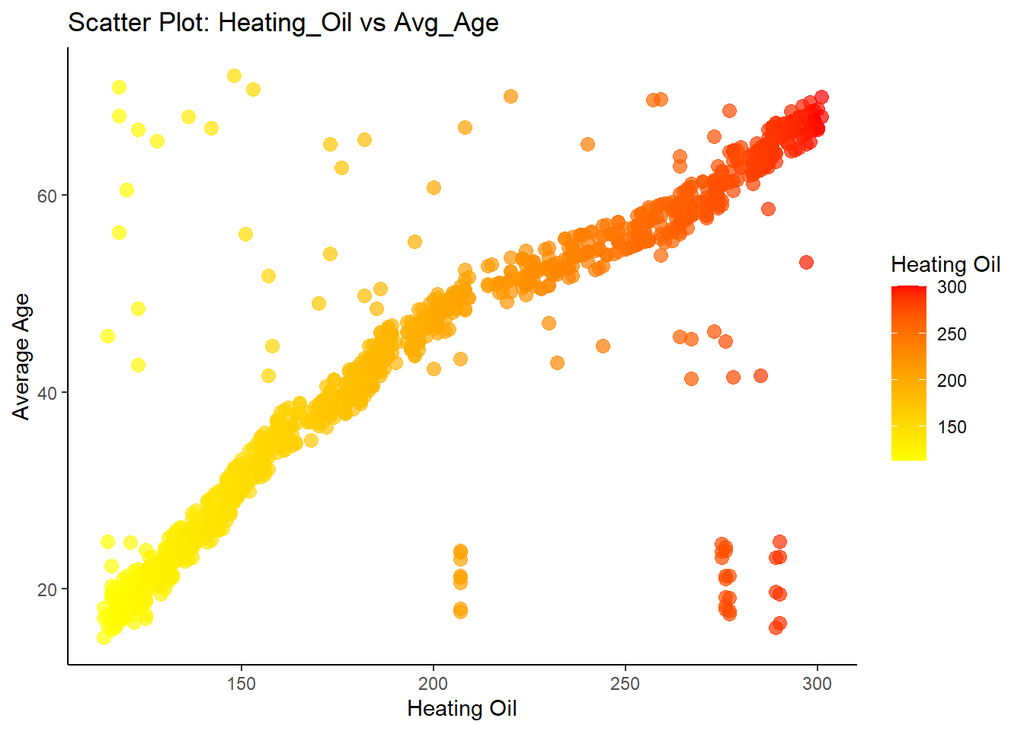

```r
library(ggplot2)

ggplot(HeatingOil, aes(x = Heating_Oil, y = Avg_Age, color = Heating_Oil)) +
  geom_point(size = 3, alpha = 0.7) +
  scale_color_gradient(low = "yellow", high = "red") +
  labs(title = "Scatter Plot: Heating_Oil vs Avg_Age",
       x = "Heating Oil",
       y = "Average Age",
       color = "Heating Oil") +
  theme_classic()
```

Penjelasan:

Scatter plot ini menunjukkan hubungan antara Heating_Oil (konsumsi minyak pemanas) dan Avg_Age (usia rata-rata penghuni rumah). Titik-titik pada grafik diberi warna berdasarkan intensitas konsumsi heating oil—semakin merah warnanya, semakin tinggi konsumsi.

Dari hasil visualisasi, terlihat pola bahwa semakin tinggi usia rata-rata penghuni rumah, cenderung semakin tinggi konsumsi heating oil. Titik-titik dengan warna merah (konsumsi tinggi) lebih banyak muncul di bagian atas grafik (usia lebih tua).

Hal ini sejalan dengan hasil korelasi sebelumnya, yaitu terdapat korelasi positif kuat antara usia penghuni dan konsumsi heating oil.

## Scatter Plot 2

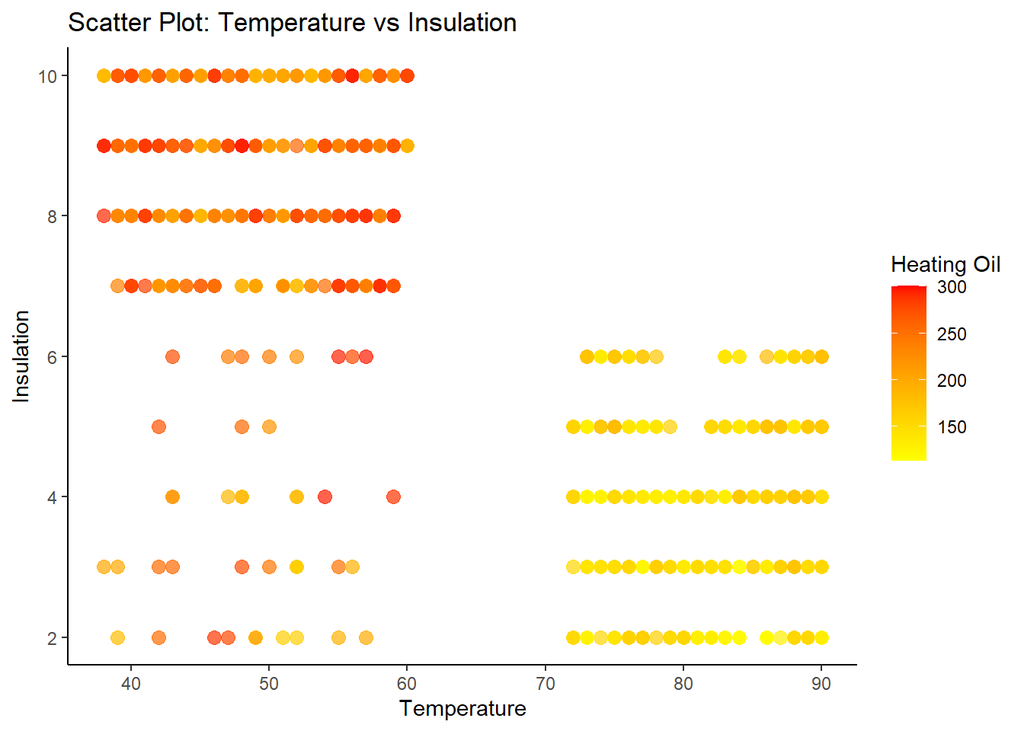

```r
ggplot(HeatingOil, aes(x = Temperature, y = Insulation, color = Heating_Oil)) +
  geom_point(size = 3, alpha = 0.7) +
  scale_color_gradient(low = "yellow", high = "red") +
  labs(title = "Scatter Plot: Temperature vs Insulation",
       x = "Temperature",
       y = "Insulation",
       color = "Heating Oil") +
  theme_classic()
```

Penjelasan:

Scatter plot ini menunjukkan hubungan antara suhu lingkungan (Temperature) dan kualitas insulasi rumah (Insulation), dengan warna titik-titik menunjukkan jumlah konsumsi heating oil (Heating_Oil). Semakin merah warnanya, semakin tinggi konsumsi minyak pemanas.

Hasil yang Terlihat:

1. **Hubungan Suhu dan Insulasi**, secara umum, tidak tampak pola linier yang jelas antara suhu dan insulasi. Namun jika mengacu pada correlation matrix sebelumnya, terdapat korelasi negatif antara keduanya (-0.79), yang berarti rumah dengan insulasi tinggi cenderung berada di wilayah yang lebih dingin.
2. **Konsumsi Heating_Oil (warna titik)**, titik-titik merah (konsumsi tinggi) lebih banyak muncul pada kombinasi suhu rendah dan insulasi tinggi. Ini sejalan dengan korelasi yang ditemukan sebelumnya:
- **Temperature** ↘ **Heating_Oil** (korelasi negatif, -0.77)
- **Insulation** ↗ **Heating_Oil** (korelasi positif, +0.74)

## Rekomendasi untuk Sarah

1. Targetkan rumah dengan penghuni lebih tua (karena mereka cenderung menggunakan lebih banyak heating oil).
2. Fokus pada rumah dengan insulasi yang baik, meskipun insulasi baik terkadang justru meningkatkan konsumsi heating oil, produk yang efisien bisa jadi solusi.
3. Tawarkan produk di daerah dengan suhu dingin, karena di tempat tersebut, konsumsi heating oil lebih tinggi.
4. Rumah besar cenderung menggunakan lebih banyak pemanas, jadi Sarah bisa fokus menawarkan produk untuk rumah yang lebih besar.
5. Komunikasi efisiensi energi akan menarik bagi pelanggan yang peduli dengan penghematan biaya dan energi.

# Soal 2

## Yang harus dilakukan Sarah

Membaca dataset: `HeatingOil.csv`

```r
library(corrplot)

# Membaca data
HeatingOil <- read.csv("HeatingOil.csv")

# Menampilkan 6 baris pertama
head(HeatingOil)
```

|  | Insulation | Temperature | Heating_Oil | Num_Occupants | Avg_Age | Home_Size |
| --- | --- | --- | --- | --- | --- | --- |
| 1 | 6 | 74 | 132 | 4 | 23.8 | 4 |
| 2 | 10 | 43 | 263 | 4 | 56.7 | 4 |
| 3 | 3 | 81 | 145 | 2 | 28.0 | 6 |
| 4 | 9 | 50 | 196 | 4 | 45.1 | 3 |
| 5 | 2 | 80 | 131 | 5 | 20.8 | 2 |
| 6 | 5 | 76 | 129 | 3 | 21.5 | 3 |

Membuat model regresi untuk memprediksi konsumsi minyak `Heating_Oil`

```r
# Memuat library tambahan untuk analisis regresi
library(tidyverse)
```

```r
# Membuat model regresi linear untuk memprediksi Heating_Oil
model <- lm(Heating_Oil ~ Insulation + Temperature + Num_Occupants + Avg_Age + Home_Size, data = HeatingOil)

# Melihat ringkasan model untuk memahami hasil regresi
summary(model)
```

```
##
## Call:
## lm(formula = Heating_Oil ~ Insulation + Temperature + Num_Occupants +
##     Avg_Age + Home_Size, data = HeatingOil)
##
## Residuals:
##      Min       1Q   Median       3Q      Max
## -103.558  -11.999    0.544   11.764  128.215
##
## Coefficients:
##                Estimate Std. Error t value Pr(>|t|)
## (Intercept)   135.48094    7.73091  17.525  < 2e-16 ***
## Insulation      3.32551    0.42044   7.910 5.78e-15 ***
## Temperature    -0.86993    0.07114 -12.228  < 2e-16 ***
## Num_Occupants  -0.26896    0.40689  -0.661    0.509
## Avg_Age         1.96582    0.06523  30.137  < 2e-16 ***
## Home_Size       3.17151    0.31088  10.202  < 2e-16 ***
## ---
## Signif. codes:  0 '***' 0.001 '**' 0.01 '*' 0.05 '.' 0.1 ' ' 1
##
## Residual standard error: 23.96 on 1212 degrees of freedom
## Multiple R-squared:  0.8193, Adjusted R-squared:  0.8186
## F-statistic:  1099 on 5 and 1212 DF,  p-value: < 2.2e-16
```

Menyimpan model agar dapat digunakan oleh marketer tanpa harus membagikan data `HeatingOil.csv`

```r
# Menyimpan model ke dalam file .rds
saveRDS(model, "heating_oil_model.rds")
```

## Yang harus dilakukan Marketer

Membaca model yang sudah disimpan oleh `Sarah`

```r
library(readr)

# Membaca model yang sudah disimpan oleh Sarah
model <- readRDS("heating_oil_model.rds")
```

Membaca data calon pelanggan baru: `HeatingOil-Marketing.csv`

```r
# Memuat library yang diperlukan
library(readr)

# Membaca data calon pelanggan baru dari file CSV
new_customers <- read.csv("HeatingOil-Marketing.csv")

# Menampilkan beberapa baris awal untuk memeriksa data
head(new_customers)
```

|  | Insulation | Temperature | Num_Occupants | Avg_Age | Home_Size |
| --- | --- | --- | --- | --- | --- |
| 1 | 6 | 74 | 4 | 23.8 | 4 |
| 2 | 10 | 43 | 4 | 56.7 | 4 |
| 3 | 3 | 81 | 2 | 28.0 | 6 |
| 4 | 9 | 50 | 4 | 45.1 | 3 |

Menerapkan model ke data calon pelanggan baru untuk memprediksi kebutuhan minyak pemanas rumah

```r
# Menerapkan model untuk memprediksi konsumsi Heating_Oil
predictions <- predict(model, newdata = new_customers)

# Menampilkan hasil prediksi
print(predictions)
```

```
##        1        2        3        4
## 149.4560 254.4012 148.5274 219.0112
```

Menyimpan Hasil Prediksi

```r
# Menyimpan hasil prediksi ke dalam file CSV
write.csv(predictions, "predictions.csv", row.names = FALSE)
```